# Optimal Treatment Analysis

## Outcome Variable

**Outcome Variable:** ever_stunted

## Predictor Variables

**Intervention Variable:** birthlen

**Adjustment Set:**

- arm
- sex
- W_mage
- meducyrs
- feducyrs
- vagbrth
- single
- brthmon
- W_parity
- delta_W_mage
- delta_meducyrs
- delta_feducyrs
- delta_vagbrth
- delta_single
- delta_brthmon
- delta_W_parity

## Stratifying Variables

The analysis was stratified on these variable(s):

- agecat
- studyid
- country

## Data Summary

| agecat | studyid | country | birthlen | ever_stunted | n_cell | n |
| --- | --- | --- | --- | --- | --- | --- |
| 0-24 months (no birth st.) | ki0047075b-MAL-ED | BANGLADESH | >=50 cm | 0 | 23 | 211 |
| 0-24 months (no birth st.) | ki0047075b-MAL-ED | BANGLADESH | >=50 cm | 1 | 6 | 211 |
| 0-24 months (no birth st.) | ki0047075b-MAL-ED | BANGLADESH | <48 cm | 0 | 33 | 211 |
| 0-24 months (no birth st.) | ki0047075b-MAL-ED | BANGLADESH | <48 cm | 1 | 64 | 211 |
| 0-24 months (no birth st.) | ki0047075b-MAL-ED | BANGLADESH | [48-50) cm | 0 | 45 | 211 |
| 0-24 months (no birth st.) | ki0047075b-MAL-ED | BANGLADESH | [48-50) cm | 1 | 40 | 211 |
| 0-24 months (no birth st.) | ki0047075b-MAL-ED | BRAZIL | >=50 cm | 0 | 33 | 170 |
| 0-24 months (no birth st.) | ki0047075b-MAL-ED | BRAZIL | >=50 cm | 1 | 1 | 170 |
| 0-24 months (no birth st.) | ki0047075b-MAL-ED | BRAZIL | <48 cm | 0 | 38 | 170 |
| 0-24 months (no birth st.) | ki0047075b-MAL-ED | BRAZIL | <48 cm | 1 | 21 | 170 |
| 0-24 months (no birth st.) | ki0047075b-MAL-ED | BRAZIL | [48-50) cm | 0 | 73 | 170 |
| 0-24 months (no birth st.) | ki0047075b-MAL-ED | BRAZIL | [48-50) cm | 1 | 4 | 170 |
| 0-24 months (no birth st.) | ki0047075b-MAL-ED | INDIA | >=50 cm | 0 | 21 | 174 |
| 0-24 months (no birth st.) | ki0047075b-MAL-ED | INDIA | >=50 cm | 1 | 4 | 174 |
| 0-24 months (no birth st.) | ki0047075b-MAL-ED | INDIA | <48 cm | 0 | 28 | 174 |
| 0-24 months (no birth st.) | ki0047075b-MAL-ED | INDIA | <48 cm | 1 | 47 | 174 |
| 0-24 months (no birth st.) | ki0047075b-MAL-ED | INDIA | [48-50) cm | 0 | 39 | 174 |
| 0-24 months (no birth st.) | ki0047075b-MAL-ED | INDIA | [48-50) cm | 1 | 35 | 174 |
| 0-24 months (no birth st.) | ki0047075b-MAL-ED | NEPAL | >=50 cm | 0 | 37 | 155 |
| 0-24 months (no birth st.) | ki0047075b-MAL-ED | NEPAL | >=50 cm | 1 | 1 | 155 |
| 0-24 months (no birth st.) | ki0047075b-MAL-ED | NEPAL | <48 cm | 0 | 30 | 155 |
| 0-24 months (no birth st.) | ki0047075b-MAL-ED | NEPAL | <48 cm | 1 | 21 | 155 |
| 0-24 months (no birth st.) | ki0047075b-MAL-ED | NEPAL | [48-50) cm | 0 | 48 | 155 |
| 0-24 months (no birth st.) | ki0047075b-MAL-ED | NEPAL | [48-50) cm | 1 | 18 | 155 |
| 0-24 months (no birth st.) | ki0047075b-MAL-ED | PERU | >=50 cm | 0 | 21 | 255 |
| 0-24 months (no birth st.) | ki0047075b-MAL-ED | PERU | >=50 cm | 1 | 13 | 255 |
| 0-24 months (no birth st.) | ki0047075b-MAL-ED | PERU | <48 cm | 0 | 31 | 255 |
| 0-24 months (no birth st.) | ki0047075b-MAL-ED | PERU | <48 cm | 1 | 78 | 255 |
| 0-24 months (no birth st.) | ki0047075b-MAL-ED | PERU | [48-50) cm | 0 | 58 | 255 |
| 0-24 months (no birth st.) | ki0047075b-MAL-ED | PERU | [48-50) cm | 1 | 54 | 255 |

[output cut: 468 more lines]

The following strata were considered:

- agecat: 0-24 months (no birth st.), studyid: ki0047075b-MAL-ED, country: BANGLADESH
- agecat: 0-24 months (no birth st.), studyid: ki0047075b-MAL-ED, country: BRAZIL
- agecat: 0-24 months (no birth st.), studyid: ki0047075b-MAL-ED, country: INDIA
- agecat: 0-24 months (no birth st.), studyid: ki0047075b-MAL-ED, country: NEPAL
- agecat: 0-24 months (no birth st.), studyid: ki0047075b-MAL-ED, country: PERU
- agecat: 0-24 months (no birth st.), studyid: ki0047075b-MAL-ED, country: SOUTH AFRICA
- agecat: 0-24 months (no birth st.), studyid: ki0047075b-MAL-ED, country: TANZANIA, UNITED REPUBLIC OF
- agecat: 0-24 months (no birth st.), studyid: ki1000108-CMC-V-BCS-2002, country: INDIA
- agecat: 0-24 months (no birth st.), studyid: ki1000108-IRC, country: INDIA
- agecat: 0-24 months (no birth st.), studyid: ki1000109-EE, country: PAKISTAN
- agecat: 0-24 months (no birth st.), studyid: ki1000109-ResPak, country: PAKISTAN
- agecat: 0-24 months (no birth st.), studyid: ki1000304b-SAS-CompFeed, country: INDIA
- agecat: 0-24 months (no birth st.), studyid: ki1017093-NIH-Birth, country: BANGLADESH
- agecat: 0-24 months (no birth st.), studyid: ki1017093b-PROVIDE, country: BANGLADESH
- agecat: 0-24 months (no birth st.), studyid: ki1017093c-NIH-Crypto, country: BANGLADESH
- agecat: 0-24 months (no birth st.), studyid: ki1101329-Keneba, country: GAMBIA
- agecat: 0-24 months (no birth st.), studyid: ki1114097-CMIN, country: BANGLADESH
- agecat: 0-24 months (no birth st.), studyid: ki1114097-CMIN, country: BRAZIL
- agecat: 0-24 months (no birth st.), studyid: ki1114097-CMIN, country: GUINEA-BISSAU
- agecat: 0-24 months (no birth st.), studyid: ki1114097-CMIN, country: PERU
- agecat: 0-24 months (no birth st.), studyid: ki1114097-CONTENT, country: PERU
- agecat: 0-24 months (no birth st.), studyid: ki1119695-PROBIT, country: BELARUS
- agecat: 0-24 months (no birth st.), studyid: ki1126311-ZVITAMBO, country: ZIMBABWE
- agecat: 0-24 months (no birth st.), studyid: ki1135781-COHORTS, country: GUATEMALA
- agecat: 0-24 months (no birth st.), studyid: ki1135781-COHORTS, country: INDIA
- agecat: 0-24 months (no birth st.), studyid: ki1135781-COHORTS, country: PHILIPPINES
- agecat: 0-24 months (no birth st.), studyid: kiGH5241-JiVitA-3, country: BANGLADESH
- agecat: 0-24 months (no birth st.), studyid: kiGH5241-JiVitA-4, country: BANGLADESH
- agecat: 0-6 months (no birth st.), studyid: ki0047075b-MAL-ED, country: BANGLADESH
- agecat: 0-6 months (no birth st.), studyid: ki0047075b-MAL-ED, country: BRAZIL
- agecat: 0-6 months (no birth st.), studyid: ki0047075b-MAL-ED, country: INDIA
- agecat: 0-6 months (no birth st.), studyid: ki0047075b-MAL-ED, country: NEPAL
- agecat: 0-6 months (no birth st.), studyid: ki0047075b-MAL-ED, country: PERU
- agecat: 0-6 months (no birth st.), studyid: ki0047075b-MAL-ED, country: SOUTH AFRICA
- agecat: 0-6 months (no birth st.), studyid: ki0047075b-MAL-ED, country: TANZANIA, UNITED REPUBLIC OF
- agecat: 0-6 months (no birth st.), studyid: ki1000108-CMC-V-BCS-2002, country: INDIA
- agecat: 0-6 months (no birth st.), studyid: ki1000108-IRC, country: INDIA
- agecat: 0-6 months (no birth st.), studyid: ki1000109-EE, country: PAKISTAN
- agecat: 0-6 months (no birth st.), studyid: ki1000109-ResPak, country: PAKISTAN
- agecat: 0-6 months (no birth st.), studyid: ki1000304b-SAS-CompFeed, country: INDIA
- agecat: 0-6 months (no birth st.), studyid: ki1017093-NIH-Birth, country: BANGLADESH
- agecat: 0-6 months (no birth st.), studyid: ki1017093b-PROVIDE, country: BANGLADESH
- agecat: 0-6 months (no birth st.), studyid: ki1017093c-NIH-Crypto, country: BANGLADESH
- agecat: 0-6 months (no birth st.), studyid: ki1101329-Keneba, country: GAMBIA
- agecat: 0-6 months (no birth st.), studyid: ki1114097-CMIN, country: BANGLADESH
- agecat: 0-6 months (no birth st.), studyid: ki1114097-CMIN, country: BRAZIL
- agecat: 0-6 months (no birth st.), studyid: ki1114097-CMIN, country: GUINEA-BISSAU
- agecat: 0-6 months (no birth st.), studyid: ki1114097-CMIN, country: PERU
- agecat: 0-6 months (no birth st.), studyid: ki1114097-CONTENT, country: PERU
- agecat: 0-6 months (no birth st.), studyid: ki1119695-PROBIT, country: BELARUS
- agecat: 0-6 months (no birth st.), studyid: ki1126311-ZVITAMBO, country: ZIMBABWE
- agecat: 0-6 months (no birth st.), studyid: ki1135781-COHORTS, country: GUATEMALA
- agecat: 0-6 months (no birth st.), studyid: ki1135781-COHORTS, country: INDIA
- agecat: 0-6 months (no birth st.), studyid: ki1135781-COHORTS, country: PHILIPPINES
- agecat: 0-6 months (no birth st.), studyid: kiGH5241-JiVitA-3, country: BANGLADESH
- agecat: 0-6 months (no birth st.), studyid: kiGH5241-JiVitA-4, country: BANGLADESH
- agecat: 6-24 months, studyid: ki0047075b-MAL-ED, country: BANGLADESH
- agecat: 6-24 months, studyid: ki0047075b-MAL-ED, country: BRAZIL
- agecat: 6-24 months, studyid: ki0047075b-MAL-ED, country: INDIA
- agecat: 6-24 months, studyid: ki0047075b-MAL-ED, country: NEPAL
- agecat: 6-24 months, studyid: ki0047075b-MAL-ED, country: PERU
- agecat: 6-24 months, studyid: ki0047075b-MAL-ED, country: SOUTH AFRICA
- agecat: 6-24 months, studyid: ki0047075b-MAL-ED, country: TANZANIA, UNITED REPUBLIC OF
- agecat: 6-24 months, studyid: ki1000108-CMC-V-BCS-2002, country: INDIA
- agecat: 6-24 months, studyid: ki1000108-IRC, country: INDIA
- agecat: 6-24 months, studyid: ki1000109-EE, country: PAKISTAN
- agecat: 6-24 months, studyid: ki1000109-ResPak, country: PAKISTAN
- agecat: 6-24 months, studyid: ki1000304b-SAS-CompFeed, country: INDIA
- agecat: 6-24 months, studyid: ki1017093-NIH-Birth, country: BANGLADESH
- agecat: 6-24 months, studyid: ki1017093b-PROVIDE, country: BANGLADESH
- agecat: 6-24 months, studyid: ki1017093c-NIH-Crypto, country: BANGLADESH
- agecat: 6-24 months, studyid: ki1101329-Keneba, country: GAMBIA
- agecat: 6-24 months, studyid: ki1114097-CMIN, country: BRAZIL
- agecat: 6-24 months, studyid: ki1114097-CMIN, country: GUINEA-BISSAU
- agecat: 6-24 months, studyid: ki1114097-CMIN, country: PERU
- agecat: 6-24 months, studyid: ki1114097-CONTENT, country: PERU
- agecat: 6-24 months, studyid: ki1119695-PROBIT, country: BELARUS
- agecat: 6-24 months, studyid: ki1126311-ZVITAMBO, country: ZIMBABWE
- agecat: 6-24 months, studyid: ki1135781-COHORTS, country: GUATEMALA
- agecat: 6-24 months, studyid: ki1135781-COHORTS, country: INDIA
- agecat: 6-24 months, studyid: ki1135781-COHORTS, country: PHILIPPINES
- agecat: 6-24 months, studyid: kiGH5241-JiVitA-3, country: BANGLADESH
- agecat: 6-24 months, studyid: kiGH5241-JiVitA-4, country: BANGLADESH

### Dropped Strata

Some strata were dropped due to rare outcomes:

- agecat: 0-24 months (no birth st.), studyid: ki0047075b-MAL-ED, country: BRAZIL
- agecat: 0-24 months (no birth st.), studyid: ki0047075b-MAL-ED, country: INDIA
- agecat: 0-24 months (no birth st.), studyid: ki0047075b-MAL-ED, country: NEPAL
- agecat: 0-24 months (no birth st.), studyid: ki1000108-CMC-V-BCS-2002, country: INDIA
- agecat: 0-24 months (no birth st.), studyid: ki1000109-EE, country: PAKISTAN
- agecat: 0-24 months (no birth st.), studyid: ki1000109-ResPak, country: PAKISTAN
- agecat: 0-24 months (no birth st.), studyid: ki1114097-CMIN, country: BANGLADESH
- agecat: 0-24 months (no birth st.), studyid: ki1114097-CMIN, country: GUINEA-BISSAU
- agecat: 0-24 months (no birth st.), studyid: ki1114097-CMIN, country: PERU
- agecat: 0-24 months (no birth st.), studyid: ki1114097-CONTENT, country: PERU
- agecat: 0-6 months (no birth st.), studyid: ki0047075b-MAL-ED, country: BANGLADESH
- agecat: 0-6 months (no birth st.), studyid: ki0047075b-MAL-ED, country: BRAZIL
- agecat: 0-6 months (no birth st.), studyid: ki0047075b-MAL-ED, country: INDIA
- agecat: 0-6 months (no birth st.), studyid: ki0047075b-MAL-ED, country: NEPAL
- agecat: 0-6 months (no birth st.), studyid: ki0047075b-MAL-ED, country: PERU
- agecat: 0-6 months (no birth st.), studyid: ki0047075b-MAL-ED, country: TANZANIA, UNITED REPUBLIC OF
- agecat: 0-6 months (no birth st.), studyid: ki1000109-EE, country: PAKISTAN
- agecat: 0-6 months (no birth st.), studyid: ki1000109-ResPak, country: PAKISTAN
- agecat: 0-6 months (no birth st.), studyid: ki1017093-NIH-Birth, country: BANGLADESH
- agecat: 0-6 months (no birth st.), studyid: ki1017093b-PROVIDE, country: BANGLADESH
- agecat: 0-6 months (no birth st.), studyid: ki1017093c-NIH-Crypto, country: BANGLADESH
- agecat: 0-6 months (no birth st.), studyid: ki1114097-CMIN, country: BANGLADESH
- agecat: 0-6 months (no birth st.), studyid: ki1114097-CMIN, country: BRAZIL
- agecat: 0-6 months (no birth st.), studyid: ki1114097-CMIN, country: GUINEA-BISSAU
- agecat: 0-6 months (no birth st.), studyid: ki1114097-CMIN, country: PERU
- agecat: 0-6 months (no birth st.), studyid: ki1114097-CONTENT, country: PERU
- agecat: 6-24 months, studyid: ki0047075b-MAL-ED, country: BRAZIL
- agecat: 6-24 months, studyid: ki0047075b-MAL-ED, country: INDIA
- agecat: 6-24 months, studyid: ki0047075b-MAL-ED, country: NEPAL
- agecat: 6-24 months, studyid: ki0047075b-MAL-ED, country: TANZANIA, UNITED REPUBLIC OF
- agecat: 6-24 months, studyid: ki1000108-CMC-V-BCS-2002, country: INDIA
- agecat: 6-24 months, studyid: ki1000109-EE, country: PAKISTAN
- agecat: 6-24 months, studyid: ki1000109-ResPak, country: PAKISTAN
- agecat: 6-24 months, studyid: ki1114097-CMIN, country: BRAZIL
- agecat: 6-24 months, studyid: ki1114097-CMIN, country: GUINEA-BISSAU
- agecat: 6-24 months, studyid: ki1114097-CMIN, country: PERU
- agecat: 6-24 months, studyid: ki1114097-CONTENT, country: PERU

## Methods Detail

We’re interested in the causal parameters $E[Y_a]$ for all values of $a \in \mathcal{A}$. These parameters represent the mean outcome if, possibly contrary to fact, we intervened to set all units to have $A=a$. Under the randomization and positivity assumptions, these are identified by the statistical parameters $\psi_a=E_W[E_{Y|A,W}(Y|A=a,W)]$. In addition, we’re interested in the mean of $Y$, $E[Y]$ under no intervention (the observed mean). We will estimate these parameters by using SuperLearner to fit the relevant likelihood factors – $E_{Y|A,W}(Y|A=a,W)$ and $p(A=a|W)$, and then updating our likelihood fit using a joint TMLE.

For unadjusted analyses ($W=\{\}$), initial likelihoods were estimated using Lrnr_glm to estimate the simple $E(Y|A)$ and Lrnr_mean to estimate $p(A)$. For adjusted analyses, a small library containing Lrnr_glmnet, Lrnr_xgboost, and Lrnr_mean was used.

Having estimated these parameters, we will then use the delta method to estimate relative risks and attributable risks relative to a prespecified baseline level of $A$.

# Results Detail

## Results Plots

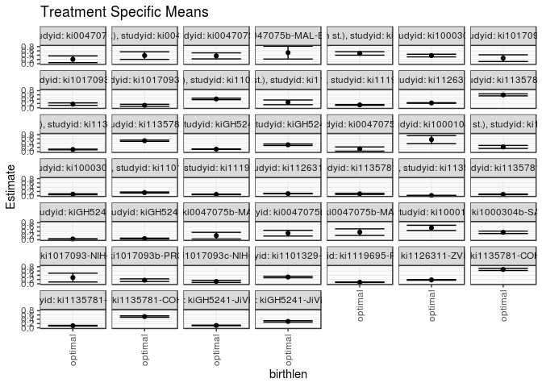

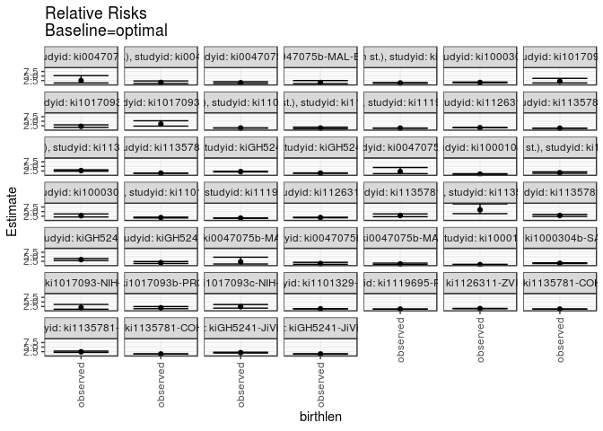

## Results Table

### Parameter: TSM

| agecat | studyid | country | intervention_level | baseline_level | estimate | ci_lower | ci_upper |
| --- | --- | --- | --- | --- | --- | --- | --- |
| 0-24 months (no birth st.) | ki0047075b-MAL-ED | BANGLADESH | optimal | NA | 0.2072474 | 0.0489593 | 0.3655356 |
| 0-24 months (no birth st.) | ki0047075b-MAL-ED | PERU | optimal | NA | 0.3809322 | 0.2040590 | 0.5578054 |
| 0-24 months (no birth st.) | ki0047075b-MAL-ED | SOUTH AFRICA | optimal | NA | 0.3660887 | 0.2246021 | 0.5075753 |
| 0-24 months (no birth st.) | ki0047075b-MAL-ED | TANZANIA, UNITED REPUBLIC OF | optimal | NA | 0.5175906 | 0.2184267 | 0.8167546 |
| 0-24 months (no birth st.) | ki1000108-IRC | INDIA | optimal | NA | 0.4815788 | 0.3994096 | 0.5637479 |
| 0-24 months (no birth st.) | ki1000304b-SAS-CompFeed | INDIA | optimal | NA | 0.3810820 | 0.3189649 | 0.4431991 |
| 0-24 months (no birth st.) | ki1017093-NIH-Birth | BANGLADESH | optimal | NA | 0.2602371 | 0.1033817 | 0.4170924 |
| 0-24 months (no birth st.) | ki1017093b-PROVIDE | BANGLADESH | optimal | NA | 0.1697134 | 0.1123559 | 0.2270708 |
| 0-24 months (no birth st.) | ki1017093c-NIH-Crypto | BANGLADESH | optimal | NA | 0.1125456 | 0.0643408 | 0.1607504 |
| 0-24 months (no birth st.) | ki1101329-Keneba | GAMBIA | optimal | NA | 0.4108964 | 0.3759897 | 0.4458032 |
| 0-24 months (no birth st.) | ki1114097-CMIN | BRAZIL | optimal | NA | 0.2519386 | 0.1426569 | 0.3612203 |
| 0-24 months (no birth st.) | ki1119695-PROBIT | BELARUS | optimal | NA | 0.1317822 | 0.1127517 | 0.1508127 |
| 0-24 months (no birth st.) | ki1126311-ZVITAMBO | ZIMBABWE | optimal | NA | 0.2217179 | 0.2089410 | 0.2344948 |
| 0-24 months (no birth st.) | ki1135781-COHORTS | GUATEMALA | optimal | NA | 0.6016018 | 0.5554712 | 0.6477324 |
| 0-24 months (no birth st.) | ki1135781-COHORTS | INDIA | optimal | NA | 0.1057721 | 0.0897396 | 0.1218045 |
| 0-24 months (no birth st.) | ki1135781-COHORTS | PHILIPPINES | optimal | NA | 0.5166008 | 0.4877331 | 0.5454686 |
| 0-24 months (no birth st.) | kiGH5241-JiVitA-3 | BANGLADESH | optimal | NA | 0.1183112 | 0.1064991 | 0.1301232 |
| 0-24 months (no birth st.) | kiGH5241-JiVitA-4 | BANGLADESH | optimal | NA | 0.3266141 | 0.2921635 | 0.3610647 |
| 0-6 months (no birth st.) | ki0047075b-MAL-ED | SOUTH AFRICA | optimal | NA | 0.1276101 | 0.0300106 | 0.2252097 |
| 0-6 months (no birth st.) | ki1000108-CMC-V-BCS-2002 | INDIA | optimal | NA | 0.5662256 | 0.3756820 | 0.7567692 |
| 0-6 months (no birth st.) | ki1000108-IRC | INDIA | optimal | NA | 0.2258305 | 0.1557225 | 0.2959386 |
| 0-6 months (no birth st.) | ki1000304b-SAS-CompFeed | INDIA | optimal | NA | 0.0705705 | 0.0494800 | 0.0916611 |
| 0-6 months (no birth st.) | ki1101329-Keneba | GAMBIA | optimal | NA | 0.1503030 | 0.1246949 | 0.1759112 |
| 0-6 months (no birth st.) | ki1119695-PROBIT | BELARUS | optimal | NA | 0.0641292 | 0.0519287 | 0.0763297 |
| 0-6 months (no birth st.) | ki1126311-ZVITAMBO | ZIMBABWE | optimal | NA | 0.0993973 | 0.0901820 | 0.1086127 |
| 0-6 months (no birth st.) | ki1135781-COHORTS | GUATEMALA | optimal | NA | 0.0903635 | 0.0628322 | 0.1178949 |
| 0-6 months (no birth st.) | ki1135781-COHORTS | INDIA | optimal | NA | 0.0132785 | 0.0073461 | 0.0192109 |
| 0-6 months (no birth st.) | ki1135781-COHORTS | PHILIPPINES | optimal | NA | 0.0663153 | 0.0516194 | 0.0810112 |
| 0-6 months (no birth st.) | kiGH5241-JiVitA-3 | BANGLADESH | optimal | NA | 0.0385849 | 0.0318632 | 0.0453065 |
| 0-6 months (no birth st.) | kiGH5241-JiVitA-4 | BANGLADESH | optimal | NA | 0.0561586 | 0.0363670 | 0.0759502 |
| 6-24 months | ki0047075b-MAL-ED | BANGLADESH | optimal | NA | 0.1921066 | 0.0362507 | 0.3479625 |
| 6-24 months | ki0047075b-MAL-ED | PERU | optimal | NA | 0.3095284 | 0.1744731 | 0.4445838 |
| 6-24 months | ki0047075b-MAL-ED | SOUTH AFRICA | optimal | NA | 0.3587978 | 0.2057055 | 0.5118902 |
| 6-24 months | ki1000108-IRC | INDIA | optimal | NA | 0.5573625 | 0.4358370 | 0.6788880 |
| 6-24 months | ki1000304b-SAS-CompFeed | INDIA | optimal | NA | 0.3487996 | 0.2918249 | 0.4057743 |
| 6-24 months | ki1017093-NIH-Birth | BANGLADESH | optimal | NA | 0.2905972 | 0.0851357 | 0.4960586 |
| 6-24 months | ki1017093b-PROVIDE | BANGLADESH | optimal | NA | 0.1688154 | 0.1074307 | 0.2302002 |
| 6-24 months | ki1017093c-NIH-Crypto | BANGLADESH | optimal | NA | 0.1100916 | 0.0616559 | 0.1585272 |
| 6-24 months | ki1101329-Keneba | GAMBIA | optimal | NA | 0.3160262 | 0.2796279 | 0.3524246 |
| 6-24 months | ki1119695-PROBIT | BELARUS | optimal | NA | 0.0723937 | 0.0586573 | 0.0861300 |
| 6-24 months | ki1126311-ZVITAMBO | ZIMBABWE | optimal | NA | 0.1829329 | 0.1683738 | 0.1974920 |
| 6-24 months | ki1135781-COHORTS | GUATEMALA | optimal | NA | 0.6737035 | 0.6228512 | 0.7245558 |
| 6-24 months | ki1135781-COHORTS | INDIA | optimal | NA | 0.1005342 | 0.0841984 | 0.1168700 |
| 6-24 months | ki1135781-COHORTS | PHILIPPINES | optimal | NA | 0.5265849 | 0.4952711 | 0.5578986 |
| 6-24 months | kiGH5241-JiVitA-3 | BANGLADESH | optimal | NA | 0.1102776 | 0.0956336 | 0.1249217 |
| 6-24 months | kiGH5241-JiVitA-4 | BANGLADESH | optimal | NA | 0.2983030 | 0.2646870 | 0.3319189 |

### Parameter: E(Y)

| agecat | studyid | country | intervention_level | baseline_level | estimate | ci_lower | ci_upper |
| --- | --- | --- | --- | --- | --- | --- | --- |
| 0-24 months (no birth st.) | ki0047075b-MAL-ED | BANGLADESH | observed | NA | 0.5213270 | 0.4537634 | 0.5888907 |
| 0-24 months (no birth st.) | ki0047075b-MAL-ED | PERU | observed | NA | 0.5686275 | 0.5077199 | 0.6295350 |
| 0-24 months (no birth st.) | ki0047075b-MAL-ED | SOUTH AFRICA | observed | NA | 0.4957265 | 0.4315281 | 0.5599249 |
| 0-24 months (no birth st.) | ki0047075b-MAL-ED | TANZANIA, UNITED REPUBLIC OF | observed | NA | 0.7592593 | 0.6782516 | 0.8402669 |
| 0-24 months (no birth st.) | ki1000108-IRC | INDIA | observed | NA | 0.5913043 | 0.5393557 | 0.6432530 |
| 0-24 months (no birth st.) | ki1000304b-SAS-CompFeed | INDIA | observed | NA | 0.5657407 | 0.5074689 | 0.6240126 |
| 0-24 months (no birth st.) | ki1017093-NIH-Birth | BANGLADESH | observed | NA | 0.5549451 | 0.4825447 | 0.6273454 |
| 0-24 months (no birth st.) | ki1017093b-PROVIDE | BANGLADESH | observed | NA | 0.3753943 | 0.3376725 | 0.4131162 |
| 0-24 months (no birth st.) | ki1017093c-NIH-Crypto | BANGLADESH | observed | NA | 0.3935681 | 0.3560687 | 0.4310676 |
| 0-24 months (no birth st.) | ki1101329-Keneba | GAMBIA | observed | NA | 0.5296120 | 0.5040796 | 0.5551444 |
| 0-24 months (no birth st.) | ki1114097-CMIN | BRAZIL | observed | NA | 0.3181818 | 0.2307425 | 0.4056211 |
| 0-24 months (no birth st.) | ki1119695-PROBIT | BELARUS | observed | NA | 0.1597778 | 0.1408215 | 0.1787342 |
| 0-24 months (no birth st.) | ki1126311-ZVITAMBO | ZIMBABWE | observed | NA | 0.3260417 | 0.3178171 | 0.3342662 |
| 0-24 months (no birth st.) | ki1135781-COHORTS | GUATEMALA | observed | NA | 0.7082294 | 0.6767491 | 0.7397098 |
| 0-24 months (no birth st.) | ki1135781-COHORTS | INDIA | observed | NA | 0.2867647 | 0.2751726 | 0.2983568 |
| 0-24 months (no birth st.) | ki1135781-COHORTS | PHILIPPINES | observed | NA | 0.6671324 | 0.6498678 | 0.6843969 |
| 0-24 months (no birth st.) | kiGH5241-JiVitA-3 | BANGLADESH | observed | NA | 0.2544613 | 0.2465893 | 0.2623333 |
| 0-24 months (no birth st.) | kiGH5241-JiVitA-4 | BANGLADESH | observed | NA | 0.4273585 | 0.4069266 | 0.4477904 |
| 0-6 months (no birth st.) | ki0047075b-MAL-ED | SOUTH AFRICA | observed | NA | 0.2735043 | 0.2162683 | 0.3307402 |
| 0-6 months (no birth st.) | ki1000108-CMC-V-BCS-2002 | INDIA | observed | NA | 0.4285714 | 0.3221077 | 0.5350351 |
| 0-6 months (no birth st.) | ki1000108-IRC | INDIA | observed | NA | 0.3478261 | 0.2974955 | 0.3981566 |
| 0-6 months (no birth st.) | ki1000304b-SAS-CompFeed | INDIA | observed | NA | 0.1946247 | 0.1703263 | 0.2189230 |
| 0-6 months (no birth st.) | ki1101329-Keneba | GAMBIA | observed | NA | 0.2552757 | 0.2329715 | 0.2775799 |
| 0-6 months (no birth st.) | ki1119695-PROBIT | BELARUS | observed | NA | 0.0912784 | 0.0781588 | 0.1043979 |
| 0-6 months (no birth st.) | ki1126311-ZVITAMBO | ZIMBABWE | observed | NA | 0.1716896 | 0.1650721 | 0.1783072 |
| 0-6 months (no birth st.) | ki1135781-COHORTS | GUATEMALA | observed | NA | 0.2581047 | 0.2278007 | 0.2884088 |
| 0-6 months (no birth st.) | ki1135781-COHORTS | INDIA | observed | NA | 0.0790014 | 0.0720874 | 0.0859154 |
| 0-6 months (no birth st.) | ki1135781-COHORTS | PHILIPPINES | observed | NA | 0.1893119 | 0.1749594 | 0.2036645 |
| 0-6 months (no birth st.) | kiGH5241-JiVitA-3 | BANGLADESH | observed | NA | 0.1321472 | 0.1264309 | 0.1378635 |
| 0-6 months (no birth st.) | kiGH5241-JiVitA-4 | BANGLADESH | observed | NA | 0.0984277 | 0.0855770 | 0.1112784 |
| 6-24 months | ki0047075b-MAL-ED | BANGLADESH | observed | NA | 0.4230769 | 0.3453000 | 0.5008539 |
| 6-24 months | ki0047075b-MAL-ED | PERU | observed | NA | 0.3958333 | 0.3156813 | 0.4759854 |
| 6-24 months | ki0047075b-MAL-ED | SOUTH AFRICA | observed | NA | 0.3795620 | 0.2980035 | 0.4611205 |
| 6-24 months | ki1000108-IRC | INDIA | observed | NA | 0.3733333 | 0.3099915 | 0.4366752 |
| 6-24 months | ki1000304b-SAS-CompFeed | INDIA | observed | NA | 0.5006242 | 0.4555100 | 0.5457384 |
| 6-24 months | ki1017093-NIH-Birth | BANGLADESH | observed | NA | 0.5471698 | 0.4519599 | 0.6423797 |
| 6-24 months | ki1017093b-PROVIDE | BANGLADESH | observed | NA | 0.2997812 | 0.2577294 | 0.3418330 |
| 6-24 months | ki1017093c-NIH-Crypto | BANGLADESH | observed | NA | 0.2628458 | 0.2244546 | 0.3012371 |
| 6-24 months | ki1101329-Keneba | GAMBIA | observed | NA | 0.3816288 | 0.3523153 | 0.4109422 |
| 6-24 months | ki1119695-PROBIT | BELARUS | observed | NA | 0.0768510 | 0.0628857 | 0.0908164 |
| 6-24 months | ki1126311-ZVITAMBO | ZIMBABWE | observed | NA | 0.2452926 | 0.2357801 | 0.2548051 |
| 6-24 months | ki1135781-COHORTS | GUATEMALA | observed | NA | 0.7234469 | 0.6841620 | 0.7627318 |
| 6-24 months | ki1135781-COHORTS | INDIA | observed | NA | 0.2424242 | 0.2305635 | 0.2542850 |
| 6-24 months | ki1135781-COHORTS | PHILIPPINES | observed | NA | 0.6465028 | 0.6261291 | 0.6668766 |
| 6-24 months | kiGH5241-JiVitA-3 | BANGLADESH | observed | NA | 0.2160248 | 0.2065944 | 0.2254552 |
| 6-24 months | kiGH5241-JiVitA-4 | BANGLADESH | observed | NA | 0.3663989 | 0.3454886 | 0.3873091 |

### Parameter: RR

| agecat | studyid | country | intervention_level | baseline_level | estimate | ci_lower | ci_upper |
| --- | --- | --- | --- | --- | --- | --- | --- |
| 0-24 months (no birth st.) | ki0047075b-MAL-ED | BANGLADESH | observed | optimal | 2.5154815 | 1.2054373 | 5.2492544 |
| 0-24 months (no birth st.) | ki0047075b-MAL-ED | PERU | observed | optimal | 1.4927262 | 0.9626744 | 2.3146262 |
| 0-24 months (no birth st.) | ki0047075b-MAL-ED | SOUTH AFRICA | observed | optimal | 1.3541158 | 0.9532008 | 1.9236552 |
| 0-24 months (no birth st.) | ki0047075b-MAL-ED | TANZANIA, UNITED REPUBLIC OF | observed | optimal | 1.4669108 | 0.8541703 | 2.5192017 |
| 0-24 months (no birth st.) | ki1000108-IRC | INDIA | observed | optimal | 1.2278456 | 1.0762824 | 1.4007520 |
| 0-24 months (no birth st.) | ki1000304b-SAS-CompFeed | INDIA | observed | optimal | 1.4845643 | 1.2782302 | 1.7242052 |
| 0-24 months (no birth st.) | ki1017093-NIH-Birth | BANGLADESH | observed | optimal | 2.1324597 | 1.2101992 | 3.7575504 |
| 0-24 months (no birth st.) | ki1017093b-PROVIDE | BANGLADESH | observed | optimal | 2.2119311 | 1.6198505 | 3.0204266 |
| 0-24 months (no birth st.) | ki1017093c-NIH-Crypto | BANGLADESH | observed | optimal | 3.4969666 | 2.3274709 | 5.2541046 |
| 0-24 months (no birth st.) | ki1101329-Keneba | GAMBIA | observed | optimal | 1.2889185 | 1.2130680 | 1.3695117 |
| 0-24 months (no birth st.) | ki1114097-CMIN | BRAZIL | observed | optimal | 1.2629341 | 0.9272595 | 1.7201254 |
| 0-24 months (no birth st.) | ki1119695-PROBIT | BELARUS | observed | optimal | 1.2124380 | 1.1526242 | 1.2753558 |
| 0-24 months (no birth st.) | ki1126311-ZVITAMBO | ZIMBABWE | observed | optimal | 1.4705246 | 1.3992585 | 1.5454205 |
| 0-24 months (no birth st.) | ki1135781-COHORTS | GUATEMALA | observed | optimal | 1.1772396 | 1.1205067 | 1.2368449 |
| 0-24 months (no birth st.) | ki1135781-COHORTS | INDIA | observed | optimal | 2.7111575 | 2.3501747 | 3.1275866 |
| 0-24 months (no birth st.) | ki1135781-COHORTS | PHILIPPINES | observed | optimal | 1.2913885 | 1.2367650 | 1.3484246 |
| 0-24 months (no birth st.) | kiGH5241-JiVitA-3 | BANGLADESH | observed | optimal | 2.1507805 | 1.9614614 | 2.3583725 |
| 0-24 months (no birth st.) | kiGH5241-JiVitA-4 | BANGLADESH | observed | optimal | 1.3084507 | 1.1970516 | 1.4302168 |
| 0-6 months (no birth st.) | ki0047075b-MAL-ED | SOUTH AFRICA | observed | optimal | 2.1432802 | 1.0413834 | 4.4111036 |
| 0-6 months (no birth st.) | ki1000108-CMC-V-BCS-2002 | INDIA | observed | optimal | 0.7568916 | 0.5843479 | 0.9803832 |
| 0-6 months (no birth st.) | ki1000108-IRC | INDIA | observed | optimal | 1.5402084 | 1.1904514 | 1.9927245 |
| 0-6 months (no birth st.) | ki1000304b-SAS-CompFeed | INDIA | observed | optimal | 2.7578736 | 2.0470283 | 3.7155650 |
| 0-6 months (no birth st.) | ki1101329-Keneba | GAMBIA | observed | optimal | 1.6984069 | 1.4801640 | 1.9488286 |
| 0-6 months (no birth st.) | ki1119695-PROBIT | BELARUS | observed | optimal | 1.4233509 | 1.3047093 | 1.5527810 |
| 0-6 months (no birth st.) | ki1126311-ZVITAMBO | ZIMBABWE | observed | optimal | 1.7273065 | 1.5906269 | 1.8757308 |
| 0-6 months (no birth st.) | ki1135781-COHORTS | GUATEMALA | observed | optimal | 2.8562936 | 2.1867174 | 3.7308951 |
| 0-6 months (no birth st.) | ki1135781-COHORTS | INDIA | observed | optimal | 5.9495686 | 3.8440783 | 9.2082843 |
| 0-6 months (no birth st.) | ki1135781-COHORTS | PHILIPPINES | observed | optimal | 2.8547256 | 2.3315510 | 3.4952948 |
| 0-6 months (no birth st.) | kiGH5241-JiVitA-3 | BANGLADESH | observed | optimal | 3.4248461 | 2.9057560 | 4.0366675 |
| 0-6 months (no birth st.) | kiGH5241-JiVitA-4 | BANGLADESH | observed | optimal | 1.7526723 | 1.2931810 | 2.3754293 |
| 6-24 months | ki0047075b-MAL-ED | BANGLADESH | observed | optimal | 2.2023030 | 1.0184493 | 4.7622780 |
| 6-24 months | ki0047075b-MAL-ED | PERU | observed | optimal | 1.2788271 | 0.8525123 | 1.9183287 |
| 6-24 months | ki0047075b-MAL-ED | SOUTH AFRICA | observed | optimal | 1.0578716 | 0.7469861 | 1.4981434 |
| 6-24 months | ki1000108-IRC | INDIA | observed | optimal | 0.6698214 | 0.5448096 | 0.8235185 |
| 6-24 months | ki1000304b-SAS-CompFeed | INDIA | observed | optimal | 1.4352775 | 1.2374746 | 1.6646980 |
| 6-24 months | ki1017093-NIH-Birth | BANGLADESH | observed | optimal | 1.8829151 | 0.9773185 | 3.6276498 |
| 6-24 months | ki1017093b-PROVIDE | BANGLADESH | observed | optimal | 1.7757924 | 1.2851493 | 2.4537526 |
| 6-24 months | ki1017093c-NIH-Crypto | BANGLADESH | observed | optimal | 2.3875204 | 1.5948653 | 3.5741285 |
| 6-24 months | ki1101329-Keneba | GAMBIA | observed | optimal | 1.2075858 | 1.1179235 | 1.3044394 |
| 6-24 months | ki1119695-PROBIT | BELARUS | observed | optimal | 1.0615713 | 1.0217958 | 1.1028952 |
| 6-24 months | ki1126311-ZVITAMBO | ZIMBABWE | observed | optimal | 1.3408886 | 1.2536460 | 1.4342026 |
| 6-24 months | ki1135781-COHORTS | GUATEMALA | observed | optimal | 1.0738357 | 1.0306594 | 1.1188207 |
| 6-24 months | ki1135781-COHORTS | INDIA | observed | optimal | 2.4113612 | 2.0720820 | 2.8061935 |
| 6-24 months | ki1135781-COHORTS | PHILIPPINES | observed | optimal | 1.2277277 | 1.1754434 | 1.2823376 |
| 6-24 months | kiGH5241-JiVitA-3 | BANGLADESH | observed | optimal | 1.9589180 | 1.7346989 | 2.2121187 |
| 6-24 months | kiGH5241-JiVitA-4 | BANGLADESH | observed | optimal | 1.2282776 | 1.1172445 | 1.3503453 |

### Parameter: PAR

| agecat | studyid | country | intervention_level | baseline_level | estimate | ci_lower | ci_upper |
| --- | --- | --- | --- | --- | --- | --- | --- |
| 0-24 months (no birth st.) | ki0047075b-MAL-ED | BANGLADESH | optimal | NA | 0.3140796 | 0.1616124 | 0.4665468 |
| 0-24 months (no birth st.) | ki0047075b-MAL-ED | PERU | optimal | NA | 0.1876953 | 0.0219021 | 0.3534884 |
| 0-24 months (no birth st.) | ki0047075b-MAL-ED | SOUTH AFRICA | optimal | NA | 0.1296378 | 0.0017416 | 0.2575340 |
| 0-24 months (no birth st.) | ki0047075b-MAL-ED | TANZANIA, UNITED REPUBLIC OF | optimal | NA | 0.2416686 | -0.0326085 | 0.5159458 |
| 0-24 months (no birth st.) | ki1000108-IRC | INDIA | optimal | NA | 0.1097256 | 0.0472343 | 0.1722168 |
| 0-24 months (no birth st.) | ki1000304b-SAS-CompFeed | INDIA | optimal | NA | 0.1846587 | 0.1208893 | 0.2484282 |
| 0-24 months (no birth st.) | ki1017093-NIH-Birth | BANGLADESH | optimal | NA | 0.2947080 | 0.1488781 | 0.4405379 |
| 0-24 months (no birth st.) | ki1017093b-PROVIDE | BANGLADESH | optimal | NA | 0.2056809 | 0.1511312 | 0.2602307 |
| 0-24 months (no birth st.) | ki1017093c-NIH-Crypto | BANGLADESH | optimal | NA | 0.2810226 | 0.2305915 | 0.3314536 |
| 0-24 months (no birth st.) | ki1101329-Keneba | GAMBIA | optimal | NA | 0.1187156 | 0.0943314 | 0.1430998 |
| 0-24 months (no birth st.) | ki1114097-CMIN | BRAZIL | optimal | NA | 0.0662433 | -0.0118826 | 0.1443691 |
| 0-24 months (no birth st.) | ki1119695-PROBIT | BELARUS | optimal | NA | 0.0279956 | 0.0216774 | 0.0343137 |
| 0-24 months (no birth st.) | ki1126311-ZVITAMBO | ZIMBABWE | optimal | NA | 0.1043237 | 0.0932231 | 0.1154244 |
| 0-24 months (no birth st.) | ki1135781-COHORTS | GUATEMALA | optimal | NA | 0.1066276 | 0.0781419 | 0.1351134 |
| 0-24 months (no birth st.) | ki1135781-COHORTS | INDIA | optimal | NA | 0.1809926 | 0.1647371 | 0.1972482 |
| 0-24 months (no birth st.) | ki1135781-COHORTS | PHILIPPINES | optimal | NA | 0.1505316 | 0.1288942 | 0.1721689 |
| 0-24 months (no birth st.) | kiGH5241-JiVitA-3 | BANGLADESH | optimal | NA | 0.1361502 | 0.1248281 | 0.1474723 |
| 0-24 months (no birth st.) | kiGH5241-JiVitA-4 | BANGLADESH | optimal | NA | 0.1007444 | 0.0718046 | 0.1296841 |
| 0-6 months (no birth st.) | ki0047075b-MAL-ED | SOUTH AFRICA | optimal | NA | 0.1458941 | 0.0508149 | 0.2409734 |
| 0-6 months (no birth st.) | ki1000108-CMC-V-BCS-2002 | INDIA | optimal | NA | -0.1376542 | -0.2840428 | 0.0087344 |
| 0-6 months (no birth st.) | ki1000108-IRC | INDIA | optimal | NA | 0.1219955 | 0.0633009 | 0.1806901 |
| 0-6 months (no birth st.) | ki1000304b-SAS-CompFeed | INDIA | optimal | NA | 0.1240541 | 0.0955114 | 0.1525968 |
| 0-6 months (no birth st.) | ki1101329-Keneba | GAMBIA | optimal | NA | 0.1049727 | 0.0832384 | 0.1267069 |
| 0-6 months (no birth st.) | ki1119695-PROBIT | BELARUS | optimal | NA | 0.0271492 | 0.0214467 | 0.0328516 |
| 0-6 months (no birth st.) | ki1126311-ZVITAMBO | ZIMBABWE | optimal | NA | 0.0722923 | 0.0637692 | 0.0808154 |
| 0-6 months (no birth st.) | ki1135781-COHORTS | GUATEMALA | optimal | NA | 0.1677412 | 0.1385175 | 0.1969649 |
| 0-6 months (no birth st.) | ki1135781-COHORTS | INDIA | optimal | NA | 0.0657229 | 0.0576168 | 0.0738290 |
| 0-6 months (no birth st.) | ki1135781-COHORTS | PHILIPPINES | optimal | NA | 0.1229966 | 0.1072556 | 0.1387377 |
| 0-6 months (no birth st.) | kiGH5241-JiVitA-3 | BANGLADESH | optimal | NA | 0.0935623 | 0.0863982 | 0.1007265 |
| 0-6 months (no birth st.) | kiGH5241-JiVitA-4 | BANGLADESH | optimal | NA | 0.0422690 | 0.0253265 | 0.0592116 |
| 6-24 months | ki0047075b-MAL-ED | BANGLADESH | optimal | NA | 0.2309703 | 0.0811743 | 0.3807663 |
| 6-24 months | ki0047075b-MAL-ED | PERU | optimal | NA | 0.0863049 | -0.0420005 | 0.2146104 |
| 6-24 months | ki0047075b-MAL-ED | SOUTH AFRICA | optimal | NA | 0.0207642 | -0.1037233 | 0.1452517 |
| 6-24 months | ki1000108-IRC | INDIA | optimal | NA | -0.1840292 | -0.2925556 | -0.0755027 |
| 6-24 months | ki1000304b-SAS-CompFeed | INDIA | optimal | NA | 0.1518246 | 0.0966533 | 0.2069959 |
| 6-24 months | ki1017093-NIH-Birth | BANGLADESH | optimal | NA | 0.2565726 | 0.0685417 | 0.4446036 |
| 6-24 months | ki1017093b-PROVIDE | BANGLADESH | optimal | NA | 0.1309657 | 0.0749184 | 0.1870131 |
| 6-24 months | ki1017093c-NIH-Crypto | BANGLADESH | optimal | NA | 0.1527543 | 0.1046717 | 0.2008369 |
| 6-24 months | ki1101329-Keneba | GAMBIA | optimal | NA | 0.0656026 | 0.0413013 | 0.0899038 |
| 6-24 months | ki1119695-PROBIT | BELARUS | optimal | NA | 0.0044574 | 0.0016631 | 0.0072516 |
| 6-24 months | ki1126311-ZVITAMBO | ZIMBABWE | optimal | NA | 0.0623597 | 0.0499564 | 0.0747631 |
| 6-24 months | ki1135781-COHORTS | GUATEMALA | optimal | NA | 0.0497434 | 0.0226139 | 0.0768728 |
| 6-24 months | ki1135781-COHORTS | INDIA | optimal | NA | 0.1418901 | 0.1255771 | 0.1582030 |
| 6-24 months | ki1135781-COHORTS | PHILIPPINES | optimal | NA | 0.1199179 | 0.0975915 | 0.1422444 |
| 6-24 months | kiGH5241-JiVitA-3 | BANGLADESH | optimal | NA | 0.1057472 | 0.0919664 | 0.1195280 |
| 6-24 months | kiGH5241-JiVitA-4 | BANGLADESH | optimal | NA | 0.0680959 | 0.0397326 | 0.0964592 |

### Parameter: PAF

| agecat | studyid | country | intervention_level | baseline_level | estimate | ci_lower | ci_upper |
| --- | --- | --- | --- | --- | --- | --- | --- |
| 0-24 months (no birth st.) | ki0047075b-MAL-ED | BANGLADESH | optimal | NA | 0.6024618 | 0.1704256 | 0.8094968 |
| 0-24 months (no birth st.) | ki0047075b-MAL-ED | PERU | optimal | NA | 0.3300848 | -0.0387728 | 0.5679648 |
| 0-24 months (no birth st.) | ki0047075b-MAL-ED | SOUTH AFRICA | optimal | NA | 0.2615107 | -0.0490969 | 0.4801563 |
| 0-24 months (no birth st.) | ki0047075b-MAL-ED | TANZANIA, UNITED REPUBLIC OF | optimal | NA | 0.3182953 | -0.1707267 | 0.6030488 |
| 0-24 months (no birth st.) | ki1000108-IRC | INDIA | optimal | NA | 0.1855653 | 0.0708758 | 0.2860977 |
| 0-24 months (no birth st.) | ki1000304b-SAS-CompFeed | INDIA | optimal | NA | 0.3264017 | 0.2176683 | 0.4200226 |
| 0-24 months (no birth st.) | ki1017093-NIH-Birth | BANGLADESH | optimal | NA | 0.5310580 | 0.1736898 | 0.7338692 |
| 0-24 months (no birth st.) | ki1017093b-PROVIDE | BANGLADESH | optimal | NA | 0.5479064 | 0.3826591 | 0.6689209 |
| 0-24 months (no birth st.) | ki1017093c-NIH-Crypto | BANGLADESH | optimal | NA | 0.7140379 | 0.5703491 | 0.8096726 |
| 0-24 months (no birth st.) | ki1101329-Keneba | GAMBIA | optimal | NA | 0.2241557 | 0.1756439 | 0.2698127 |
| 0-24 months (no birth st.) | ki1114097-CMIN | BRAZIL | optimal | NA | 0.2081931 | -0.0784467 | 0.4186470 |
| 0-24 months (no birth st.) | ki1119695-PROBIT | BELARUS | optimal | NA | 0.1752156 | 0.1324145 | 0.2159051 |
| 0-24 months (no birth st.) | ki1126311-ZVITAMBO | ZIMBABWE | optimal | NA | 0.3199706 | 0.2853358 | 0.3529269 |
| 0-24 months (no birth st.) | ki1135781-COHORTS | GUATEMALA | optimal | NA | 0.1505552 | 0.1075466 | 0.1914912 |
| 0-24 months (no birth st.) | ki1135781-COHORTS | INDIA | optimal | NA | 0.6311539 | 0.5744997 | 0.6802646 |
| 0-24 months (no birth st.) | ki1135781-COHORTS | PHILIPPINES | optimal | NA | 0.2256397 | 0.1914389 | 0.2583939 |
| 0-24 months (no birth st.) | kiGH5241-JiVitA-3 | BANGLADESH | optimal | NA | 0.5350525 | 0.4901761 | 0.5759788 |
| 0-24 months (no birth st.) | kiGH5241-JiVitA-4 | BANGLADESH | optimal | NA | 0.2357374 | 0.1646141 | 0.3008053 |
| 0-6 months (no birth st.) | ki0047075b-MAL-ED | SOUTH AFRICA | optimal | NA | 0.5334255 | 0.0397389 | 0.7732994 |
| 0-6 months (no birth st.) | ki1000108-CMC-V-BCS-2002 | INDIA | optimal | NA | -0.3211932 | -0.7113092 | -0.0200093 |
| 0-6 months (no birth st.) | ki1000108-IRC | INDIA | optimal | NA | 0.3507372 | 0.1599825 | 0.4981745 |
| 0-6 months (no birth st.) | ki1000304b-SAS-CompFeed | INDIA | optimal | NA | 0.6374018 | 0.5114870 | 0.7308619 |
| 0-6 months (no birth st.) | ki1101329-Keneba | GAMBIA | optimal | NA | 0.4112129 | 0.3243992 | 0.4868713 |
| 0-6 months (no birth st.) | ki1119695-PROBIT | BELARUS | optimal | NA | 0.2974326 | 0.2335458 | 0.3559942 |
| 0-6 months (no birth st.) | ki1126311-ZVITAMBO | ZIMBABWE | optimal | NA | 0.4210640 | 0.3713171 | 0.4668745 |
| 0-6 months (no birth st.) | ki1135781-COHORTS | GUATEMALA | optimal | NA | 0.6498959 | 0.5426935 | 0.7319678 |
| 0-6 months (no birth st.) | ki1135781-COHORTS | INDIA | optimal | NA | 0.8319206 | 0.7398596 | 0.8914021 |
| 0-6 months (no birth st.) | ki1135781-COHORTS | PHILIPPINES | optimal | NA | 0.6497036 | 0.5711010 | 0.7139011 |
| 0-6 months (no birth st.) | kiGH5241-JiVitA-3 | BANGLADESH | optimal | NA | 0.7080161 | 0.6558555 | 0.7522709 |
| 0-6 months (no birth st.) | kiGH5241-JiVitA-4 | BANGLADESH | optimal | NA | 0.4294427 | 0.2267131 | 0.5790235 |
| 6-24 months | ki0047075b-MAL-ED | BANGLADESH | optimal | NA | 0.5459299 | 0.0181151 | 0.7900165 |
| 6-24 months | ki0047075b-MAL-ED | PERU | optimal | NA | 0.2180335 | -0.1730036 | 0.4787129 |
| 6-24 months | ki0047075b-MAL-ED | SOUTH AFRICA | optimal | NA | 0.0547057 | -0.3387130 | 0.3325072 |
| 6-24 months | ki1000108-IRC | INDIA | optimal | NA | -0.4929353 | -0.8355038 | -0.2143019 |
| 6-24 months | ki1000304b-SAS-CompFeed | INDIA | optimal | NA | 0.3032706 | 0.1919026 | 0.3992904 |
| 6-24 months | ki1017093-NIH-Birth | BANGLADESH | optimal | NA | 0.4689086 | -0.0232079 | 0.7243394 |
| 6-24 months | ki1017093b-PROVIDE | BANGLADESH | optimal | NA | 0.4368711 | 0.2218803 | 0.5924609 |
| 6-24 months | ki1017093c-NIH-Crypto | BANGLADESH | optimal | NA | 0.5811554 | 0.3729878 | 0.7202115 |
| 6-24 months | ki1101329-Keneba | GAMBIA | optimal | NA | 0.1719015 | 0.1054844 | 0.2333872 |
| 6-24 months | ki1119695-PROBIT | BELARUS | optimal | NA | 0.0580002 | 0.0213309 | 0.0932955 |
| 6-24 months | ki1126311-ZVITAMBO | ZIMBABWE | optimal | NA | 0.2542259 | 0.2023266 | 0.3027484 |
| 6-24 months | ki1135781-COHORTS | GUATEMALA | optimal | NA | 0.0687589 | 0.0297474 | 0.1062018 |
| 6-24 months | ki1135781-COHORTS | INDIA | optimal | NA | 0.5852965 | 0.5173936 | 0.6436454 |
| 6-24 months | ki1135781-COHORTS | PHILIPPINES | optimal | NA | 0.1854871 | 0.1492572 | 0.2201741 |
| 6-24 months | kiGH5241-JiVitA-3 | BANGLADESH | optimal | NA | 0.4895141 | 0.4235311 | 0.5479447 |
| 6-24 months | kiGH5241-JiVitA-4 | BANGLADESH | optimal | NA | 0.1858518 | 0.1049408 | 0.2594487 |